# NFPORS vs FACTS comparison

Author

Tyler L. McIntosh

Published

May 8, 2025

# Overview & Takeaways

Here we compare data from the FACTS and NFPORS databases on hazardous fuel treatments. These two databases are the most commonly used databases for recording federal fuel treatments, and have data starting in 2000. The FACTS database only contains data from USFS lands, while NFPORS has data from the Department of the Interior (DOI) as well. Note that neither database includes state or private treatments; while state prescribed burn councils have some of these numbers (see annual RX burn reports), the data is NOT spatially located. The FACTS database contains treatment perimeters, while NFPORS contains point data. The NFPORS does appear to have a separate polygon treatment layer, which we will review at the end.

For the comparison we only use data from western states, and only data on the following treatment types: “Biomass Removal”, “Broadcast Burn”, “Chipping”, “Crushing”, “Fire Use”, “Jackpot Burn”, “Lop and Scatter”, “Machine Pile”, “Machine Pile Burn”, “Thinning”, “Mastication”, “Mowing”, “Hand Pile”, “Hand Pile Burn”, and “Mastication/Mowing”. We also examine prescribed burn types specifically (Broadcast Burn, Fire Use, Jackpot Burn, Machine Pile Burn, Hand Pile Burn).

We find that the FACTS database contains data on 2024 and some already from 2025, while the NFPORS database only contains data up through 2023 (as of 5/7/2025). FACTS is clearly more actively maintained and has more recent information.

In general, NFPORS contains more treatment events and hectares treated, both for a general set of treatments (listed above), and for just the types of prescribed burning. This is driven by a higher amount of data in the earlier years of the record (i.e. 2000-2007) and by the inclusion of data from agencies other than the USFS. One caveat is that if the data is restricted to ONLY include those treatments in NFPORS that are specifically designated as “hazardous fuel reductions”, it does decrease the treatment events and area so that FACTS and NFPORS are more equivalent.

NFPORS has a polygon treatment layer that I have not seen used before. The API does not successfully return all data (throwing errors in some of the more recent years), but does return >45,000 polygons for treatments on NON-USFS lands (NPS, BIA, and BLM). When we filter these in the same way as the rest of our data, 97% of the polygons have a matching entry (by treatment ID) in the regular NFPORS database. While there are discrepancies between the area recorded in the polygon and point datasets, the area-difference histogram is heavily centered at 0, indicating that most polygons have the same area recorded in both places.

While both NFPORS and FACTS have unique treatment IDs for each event, unfortunately they do NOT appear to match, even when the NFPORS data is from FACTS, making it impossible to explicitly link the databases to gain a more comprehensive view of USFS fuel treatments.

If a user wanted comprehensive data on federal hazardous fuel treatments, options are as follow: - SIMPLEST, DON’T NEED POLYGONS: Use NFPORS points - SIMPLEST, NEED POLYGONS: Use FACTS polygons with the understanding that the data is only on USFS lands - FOR COMPREHENSIVE POLYGONS-ONLY: Use FACTS polygons + NFPORS polygons from other agencies - FOR MOST COMPREHENSIVE POLYGONS + POINTS: Use FACTS polygons + NFPORS polygons from other agencies + additional NFPORS points from non-USFS agencies

# Data overview

## NFPORS overview

“NFPORS (National Fire Plan Operations and Reporting System) is an interagency system designed to assist field personnel in planning, managing, and reporting work conducted under the program areas originally described in the 2001 National Fire Plan. It provides a consistent framework between DOI wildland fire management agencies for tracking Hazardous Fuels Reduction, Post Wildfire Recovery (including both Emergency Stabilization and Burned Area Rehabilitation),and Community Assistance activities.

NFPORS is the DOI authoritative system of record for plans and accomplishments in these specific wildland fire management activities and it allows for uniform reporting at field, regional, and national levels. The data are used for high-level decision making tools and funding for the national wildland fire program.

NFPORS began comprehensive tracking of federal Hazardous Fuels Reduction (HFR) treatments in 2003 for work funded by the National Fire Plan. Five agencies, including the Bureau of Indian Affairs, Bureau of Land Management, US Fish and Wildlife Service, National Park Service and US Forest Service provide treatment planning and accomplishment data using NFPORS. Some Treatments may be shown that were conducted prior to FY2003 primarily by the Forest Service.

Treatment Categories:

Prescribed Fire - To deliberately burn wildland fuels in either their natural or modified state and under specified environmental conditions, which allows the fire to be confined to a predetermined area and produces the fire line intensity and rate of spread required to attain planned resource management objectives.

Mechanical Fuel Treatment - HFR work that manually or mechanically removes or modifies fuel load structures to achieve fire management plans.

Other (Treatment) - HFR work that involves the use of chemicals and biological methods to achieve fire management plans. ”

For more information on NFPORS, [visit here](https://usgs.nfpors.gov/NFPORS/index.html).

Note: NFPORS data is being accessed via a REST API (URL in code). Metadata descriptions of NFPORS data fields can be [found here](https://usgs.nfpors.gov/NFPORS/help/metadata/v3_treatments_curfy_FGDC.xml).

## FACTS overview

“HazFuelTrt_PL (Hazardous Fuel Treatments - Polygon) represents activities of hazardous fuel treatment reduction that are polygons. All accomplishments toward the unified hazardous fuels reduction target must meet the following definition:”Vegetative manipulation designed to create and maintain resilient and sustainable landscapes, including burning, mechanical treatments, and/or other methods that reduce the quantity or change the arrangement of living or dead fuel so that the intensity, severity, or effects of wildland fire are reduced within acceptable ecological parameters and consistent with land management plan objectives, or activities that maintain desired fuel conditions. These conditions should be measurable or predictable using fire behavior prediction models or fire effects models.” The data came from the Forest Service’s Natural Resource Manager (NRM) Forest Activity Tracking System (FACTS), which is the agency standard for managing information about activities related to fire/fuels, silviculture, and invasive species. FACTS is an activity tracking application for all levels of the Forest Service”

FACTS data can be [downloaded here](https://data.fs.usda.gov/geodata/edw/datasets.php?xmlKeyword=Hazardous+Fuel+Treatment). FACTS metadata can be [found here](https://data.fs.usda.gov/geodata/edw/edw_resources/meta/Actv_HazFuelTrt_PL.xml).

# Setup

Access data, filter to western US and only those events that appear to have actually been completed (i.e have a completion date), remove duplicate treatment IDs, unify some naming conventions.

```r
if(!requireNamespace("here", quietly = TRUE)) {
  install.packages("here")
}
library(here)

source(here::here("code", "functions.R"))

install_and_load_packages(c("sf",
                            "here",
                            "httr",
                            "glue",
                            "patchwork",
                            "tidyverse"))
```

```
All specified packages installed and loaded.
```

```r
dir_raw <- here::here("data", "raw")
dir_ensure(dir_raw)


# Load data
facts_gdb <- here(dir_raw, "Actv_HazFuelTrt_PL.gdb")
st_layers(facts_gdb) #from https://data.fs.usda.gov/geodata/edw/datasets.php?xmlKeyword=Hazardous+Fuel+Treatment
```

```
Driver: OpenFileGDB
Available layers:
          layer_name geometry_type features fields crs_name
1 Actv_HazFuelTrt_PL Multi Polygon   652809     81    NAD83
```

```r
facts <- st_read(facts_gdb,
                 layer = "Actv_HazFuelTrt_PL",
                 quiet = TRUE)





# stream NFPORS if don't have it locally
nfpors_fl <- here(dir_raw, "nfpors_api.gpkg")
if(!file.exists(nfpors_fl)) {
  query_params <- list(where = "1=1",
                       outFields = "*",
                       f = "geojson")
  nfpors_base_url = "https://usgs.nfpors.gov/arcgis/rest/services/nfpors_treats/FeatureServer/1/QUERY"

  httr::GET(nfpors_base_url, query = query_params) #test query


  nfpors <- access_data_get_x_from_arcgis_rest_api_geojson(base_url = nfpors_base_url,
                                                           query_params = query_params,
                                                           max_record = 1000,
                                                           n = "all",
                                                           timeout = 1000)
  sf::st_write(nfpors,
               nfpors_fl,
               append = FALSE)
} else {
  nfpors <- sf::st_read(nfpors_fl, quiet = TRUE)
}


# Initial manipulation and filters

west_state_list <- c("WA", "OR", "CA", "ID", "MT", "WY", "NV", "AZ", "CO", "NM", "UT")


facts <- facts |>
  dplyr::filter(!is.na(DATE_COMPLETED)) |>
  dplyr::mutate(actualcompletionyear = year(as.Date(DATE_COMPLETED))) |>
  dplyr::filter(STATE_ABBR %in% west_state_list) |>
  dplyr::mutate(hectares = GIS_ACRES * 0.404686) |>
  dplyr::rename(stateabbr = STATE_ABBR)

nfpors <- nfpors |>
  dplyr::filter(!is.na(actualcompletiondate)) |>
  distinct(treatmentid, .keep_all = TRUE) |>
  dplyr::filter(stateabbr %in% west_state_list) |>
  dplyr::mutate(hectares = totalaccomplishment * 0.404686,
                actualcompletionyear = as.numeric(actualcompletionyear))
```

# Where is the data in NFPORS coming from & what is in it; also, what is in FACTS

NFPORS contains information on lots of things beyond fuel treatments! Let’s stick to just treatment types of “Biomass Removal”, “Broadcast Burn”, “Chipping”, “Crushing”, “Fire Use”, “Jackpot Burn”, “Lop and Scatter”, “Machine Pile”, “Machine Pile Burn”, “Thinning”, “Mastication”, “Mowing”, “Hand Pile”, “Hand Pile Burn”, and “Mastication/Mowing”.

```r
# Review and compare overall contents of each
#glimpse(nfpors)
#glimpse(facts)

# NFPORS
glue::glue("Treatment category contents: {unique(nfpors$categoryname)}")
```

```
Treatment category contents: Mechanical
Treatment category contents: Fire
Treatment category contents: N/A
Treatment category contents: Reforestation
Treatment category contents: Range
Treatment category contents: Other
Treatment category contents: Invasive Species
Treatment category contents: Erosion/Sedimentation
Treatment category contents: Preparation for Treatment
Treatment category contents: Wildlife Habitat
Treatment category contents: Roads
Treatment category contents: Facilities and Infrastructure
Treatment category contents: Trails
Treatment category contents: Facilities and Infrastructure
Treatment category contents: Insect and Disease Control
Treatment category contents: Heritage Resources
Treatment category contents: Protection and Warning
Treatment category contents: Asset Repair and Replacement
Treatment category contents: Land Ownership
Treatment category contents: Cultural and Heritage Resources
Treatment category contents: Suppression Activity Damage
Treatment category contents: Abandoned Mines
Treatment category contents: Natural Resources
Treatment category contents: Hydrologic Erosion
Treatment category contents: Terrestrial Habitat
Treatment category contents: Human Life and Safety
Treatment category contents: Riparian
Treatment category contents: Property
Treatment category contents: Soil Protection
Treatment category contents: Forestry
```

```r
# unique(nfpors$typename)
glue::glue("Purpose designation contents: {unique(nfpors$keypointname)}")
```

```
Purpose designation contents: Non-NFP
Purpose designation contents: Hazardous Fuels Reduction
Purpose designation contents: Restoration & Rehabilitation
Purpose designation contents:
```

```r
# Treatments included - commented out to avoid cluttering output
# sort(unique(nfpors$typename))
# sort(unique(facts$TREATMENT_TYPE))

# Filter to treatments of interest
treatment_types_of_interest <- c("Biomass Removal", "Broadcast Burn", "Chipping", "Crushing", "Fire Use", "Jackpot Burn", "Lop and Scatter", "Machine Pile", "Machine Pile Burn", "Thinning", "Mastication", "Mastication/Mowing", "Hand Pile", "Hand Pile Burn", "Mowing", "Biomass Removall")

facts_interest <- facts |>
    filter(TREATMENT_TYPE %in% treatment_types_of_interest)

nfpors_interest <- nfpors |>
    filter(typename %in% treatment_types_of_interest)


# Filter to only those designated for hazardous fuels reduction
nfpors_interest_designated_haz_fuels_only <- nfpors |>
  dplyr::filter(keypointname == "Hazardous Fuels Reduction")






# Filter to only prescribed burns

burn_types_of_interest <- c("Broadcast Burn", "Fire Use", "Jackpot Burn", "Machine Pile Burn", "Hand Pile Burn")

nfpors_rx <- nfpors |>
   filter(typename %in% burn_types_of_interest)

facts_rx <- facts |>
   filter(TREATMENT_TYPE %in% burn_types_of_interest)
```

# Compare overall filtered data in FACTS & NFPORS with some basic visualization

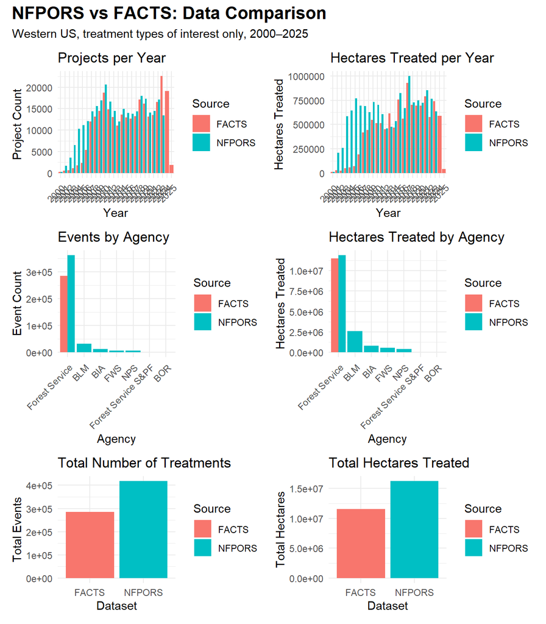

```r
compare_fuels_datasets_panel <- function(nfpors, facts, subtitle_text = "") {
  years_to_show <- 2000:2025

  # 1. Events per year
  p1_data <- bind_rows(
    nfpors |> count(Year = actualcompletionyear) |> mutate(Source = "NFPORS"),
    facts |> st_drop_geometry() |> count(Year = actualcompletionyear) |> mutate(Source = "FACTS")
  ) |> filter(Year %in% years_to_show)

  p1 <- ggplot(p1_data, aes(x = factor(Year), y = n, fill = Source)) +
    geom_bar(stat = "identity", position = "dodge") +
    labs(x = "Year", y = "Project Count", title = "Projects per Year") +
    theme_minimal() +
    theme(axis.text.x = element_text(angle = 45, hjust = 1))

  # 2. Hectares per year
  p2_data <- bind_rows(
    nfpors |> group_by(Year = actualcompletionyear) |> summarise(hectares = sum(hectares, na.rm = TRUE), .groups = "drop") |> mutate(Source = "NFPORS"),
    facts |> st_drop_geometry() |> group_by(Year = actualcompletionyear) |> summarise(hectares = sum(hectares, na.rm = TRUE), .groups = "drop") |> mutate(Source = "FACTS")
  ) |> filter(Year %in% years_to_show)

  p2 <- ggplot(p2_data, aes(x = factor(Year), y = hectares, fill = Source)) +
    geom_bar(stat = "identity", position = "dodge") +
    labs(x = "Year", y = "Hectares Treated", title = "Hectares Treated per Year") +
    theme_minimal() +
    theme(axis.text.x = element_text(angle = 45, hjust = 1))

  # 3. Events by agency
  p3_data <- bind_rows(
    nfpors |> st_drop_geometry() |> count(agencyname) |> mutate(Source = "NFPORS"),
    facts |> st_drop_geometry() |> mutate(agencyname = "Forest Service") |> count(agencyname) |> mutate(Source = "FACTS")
  )

  p3 <- ggplot(p3_data, aes(x = reorder(agencyname, -n), y = n, fill = Source)) +
    geom_bar(stat = "identity", position = "dodge") +
    labs(x = "Agency", y = "Event Count", title = "Events by Agency") +
    theme_minimal() +
    theme(axis.text.x = element_text(angle = 45, hjust = 1))

  # 4. Hectares by agency
  p4_data <- bind_rows(
    nfpors |> group_by(agencyname) |> summarise(hectares = sum(hectares, na.rm = TRUE), .groups = "drop") |> mutate(Source = "NFPORS"),
    facts |> st_drop_geometry() |> mutate(agencyname = "Forest Service") |> group_by(agencyname) |> summarise(hectares = sum(hectares, na.rm = TRUE), .groups = "drop") |> mutate(Source = "FACTS")
  )

  p4 <- ggplot(p4_data, aes(x = reorder(agencyname, -hectares), y = hectares, fill = Source)) +
    geom_bar(stat = "identity", position = "dodge") +
    labs(x = "Agency", y = "Hectares Treated", title = "Hectares Treated by Agency") +
    theme_minimal() +
    theme(axis.text.x = element_text(angle = 45, hjust = 1))

  # 5. Total event count
  p5_data <- bind_rows(
    nfpors |> summarise(value = n()) |> mutate(Source = "NFPORS"),
    facts |> st_drop_geometry() |> summarise(value = n()) |> mutate(Source = "FACTS")
  )

  p5 <- ggplot(p5_data, aes(x = Source, y = value, fill = Source)) +
    geom_bar(stat = "identity") +
    labs(x = "Dataset", y = "Total Events", title = "Total Number of Treatments") +
    theme_minimal()

  # 6. Total hectares
  p6_data <- bind_rows(
    nfpors |> summarise(value = sum(hectares, na.rm = TRUE)) |> mutate(Source = "NFPORS"),
    facts |> st_drop_geometry() |> summarise(value = sum(hectares, na.rm = TRUE)) |> mutate(Source = "FACTS")
  )

  p6 <- ggplot(p6_data, aes(x = Source, y = value, fill = Source)) +
    geom_bar(stat = "identity") +
    labs(x = "Dataset", y = "Total Hectares", title = "Total Hectares Treated") +
    theme_minimal()

  # Layout: left = count plots, right = hectares plots
  p_all <- (p1 | p2) / (p3 | p4) / (p5 | p6) +
  plot_annotation(
    title = "NFPORS vs FACTS: Data Comparison",
    subtitle = subtitle_text,
    theme = theme(plot.title = element_text(size = 16, face = "bold"))
  )

  return(invisible(p_all))
}


p1 <- compare_fuels_datasets_panel(nfpors_interest, facts_interest, subtitle_text = "Western US, treatment types of interest only, 2000–2025")
p1
```

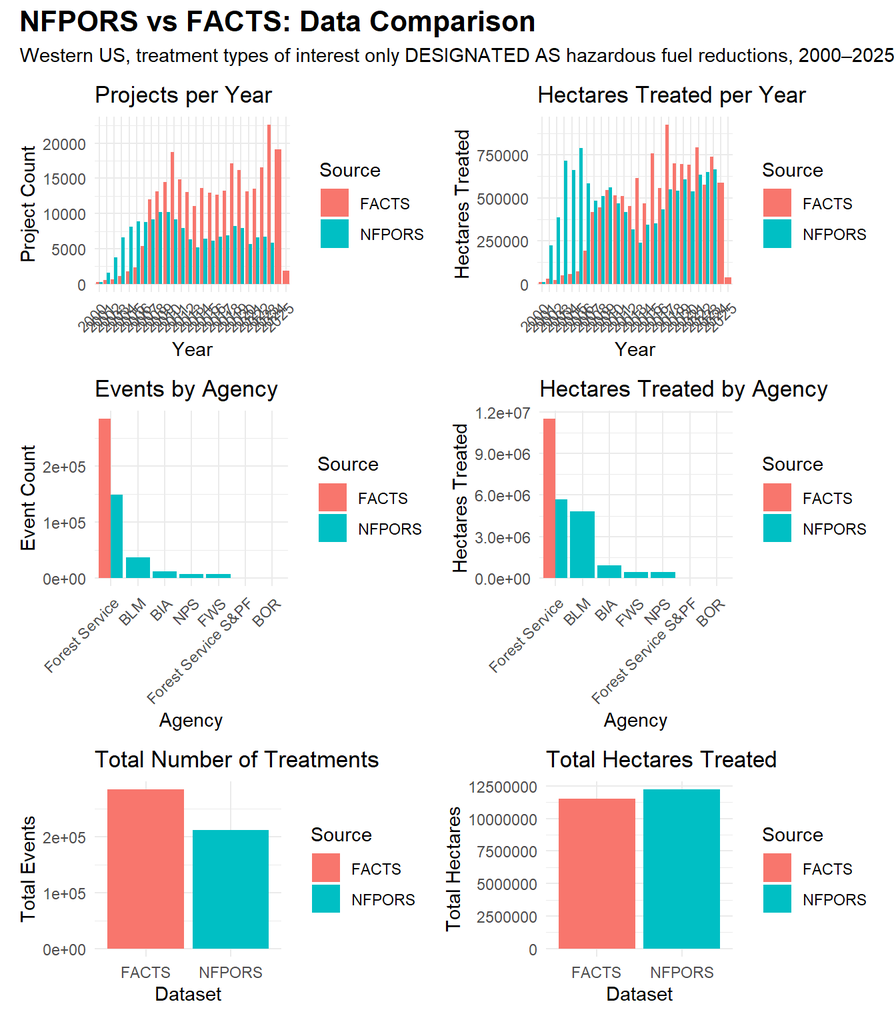

```r
p2 <- compare_fuels_datasets_panel(nfpors_interest_designated_haz_fuels_only, facts_interest, subtitle_text = "Western US, treatment types of interest only DESIGNATED AS hazardous fuel reductions, 2000–2025")
p2
```

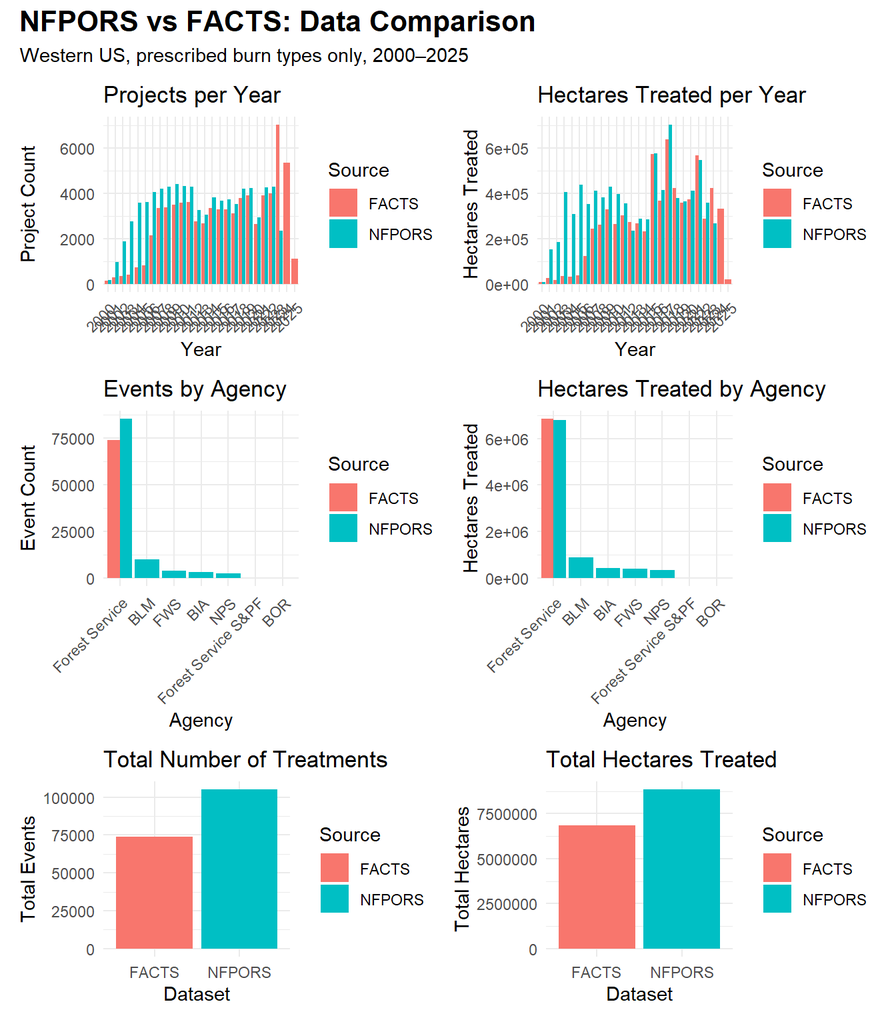

```r
p3 <- compare_fuels_datasets_panel(nfpors_rx, facts_rx, subtitle_text = "Western US, prescribed burn types only, 2000–2025")
p3
```

```r
#
# # Define years of interest
# years_to_show <- 2000:2025
#
# # Prepare NFPORS dataset
# nfpors_counts <- as.data.frame(table(nfpors$actualcompletionyear)) %>%
#   rename(Year = Var1, Count = Freq) %>%
#   mutate(Year = as.numeric(as.character(Year)),
#          Source = "NFPORS") %>%
#   filter(Year %in% years_to_show)
#
# # Prepare FACTS dataset
# facts_counts <- as.data.frame(table(facts$actualcompletionyear)) %>%
#   rename(Year = Var1, Count = Freq) %>%
#   mutate(Year = as.numeric(as.character(Year)),
#          Source = "FACTS") %>%
#   filter(Year %in% years_to_show)
#
# # Combine both
# combined_counts <- bind_rows(nfpors_counts, facts_counts)
#
# # Plot
# ggplot(combined_counts, aes(x = factor(Year), y = Count, fill = Source)) +
#   geom_bar(stat = "identity", position = "dodge") +
#   labs(x = "Year", y = "Project Count", title = "Projects per Year by Dataset\n (Western US, treatment types of interest only, 2000-2025)") +
#   theme_minimal() +
#   theme(axis.text.x = element_text(angle = 45, hjust = 1))
#
#
#
# # Aggregate total hectares by year for each dataset
# nfpors_hectares <- nfpors |>
#   group_by(actualcompletionyear) |>
#   summarise(hectares = sum(hectares, na.rm = TRUE)) |>
#   mutate(Source = "NFPORS") |>
#   rename(Year = actualcompletionyear)
#
# facts_hectares <- facts |>
#   sf::st_drop_geometry() |>
#   group_by(actualcompletionyear) |>
#   summarise(hectares = sum(hectares, na.rm = TRUE)) |>
#   mutate(Source = "FACTS") |>
#   rename(Year = actualcompletionyear)
#
# # Combine
# combined_hectares <- bind_rows(nfpors_hectares, facts_hectares) |>
#   filter(Year %in% years_to_show)
#
# # Plot
# ggplot(combined_hectares, aes(x = factor(Year), y = hectares, fill = Source)) +
#   geom_bar(stat = "identity", position = "dodge") +
#   labs(
#     x = "Year",
#     y = "Hectares Treated",
#     title = "Total Hectares Treated per Year by Dataset\n (Western US, treatment types of interest only, 2000-2025)"
#   ) +
#   theme_minimal() +
#   theme(axis.text.x = element_text(angle = 45, hjust = 1))
#
#
#
#
#
# # Aggregate total hectares by agency
# nfpors_agency_total <- nfpors |>
#   group_by(agencyname) |>
#   summarise(hectares = sum(hectares, na.rm = TRUE), .groups = "drop") |>
#   mutate(Source = "NFPORS")
#
#
# # Add Forest Service entry to match NFPORS format
# facts_agency_total <- facts |>
#   sf::st_drop_geometry() |>
#   mutate(agencyname = "Forest Service") |>
#   group_by(agencyname) |>
#   summarise(hectares = sum(hectares, na.rm = TRUE), .groups = "drop") |>
#   mutate(Source = "FACTS")
#
# # Combine both
# combined_agency_total <- bind_rows(nfpors_agency_total, facts_agency_total)
#
# # Plot
# ggplot(combined_agency_total, aes(x = reorder(agencyname, -hectares), y = hectares, fill = Source)) +
#   geom_bar(stat = "identity", position = "dodge") +
#   labs(
#     x = "Agency",
#     y = "Total Hectares Treated",
#     title = "Total Hectares Treated by Agency and Dataset\n (Western US, treatment types of interest only, 2000-2025)"
#   ) +
#   theme_minimal() +
#   theme(axis.text.x = element_text(angle = 45, hjust = 1))
#
#
# # Summarize total hectares for NFPORS
# nfpors_total <- nfpors |>
#   summarise(hectares = sum(hectares, na.rm = TRUE)) |>
#   mutate(Source = "NFPORS")
#
# # Summarize total hectares for FACTS
# facts_total <- facts |>
#   sf::st_drop_geometry() |>
#   summarise(hectares = sum(hectares, na.rm = TRUE)) |>
#   mutate(Source = "FACTS")
#
# # Combine
# total_hectares <- bind_rows(nfpors_total, facts_total)
#
# # Plot
# ggplot(total_hectares, aes(x = Source, y = hectares, fill = Source)) +
#   geom_bar(stat = "identity") +
#   labs(
#     x = "Dataset",
#     y = "Total Hectares Treated",
#     title = "Total Hectares Treated by Dataset\n (Western US, treatment types of interest only, 2000-2025)"
#   ) +
#   theme_minimal()
#
#
#
# # Count number of events (rows) in each dataset
# nfpors_events <- nfpors |>
#   summarise(events = n()) |>
#   mutate(Source = "NFPORS")
#
# facts_events <- facts |>
#   sf::st_drop_geometry() |>
#   summarise(events = n()) |>
#   mutate(Source = "FACTS")
#
# # Combine
# total_events <- bind_rows(nfpors_events, facts_events)
#
# # Plot
# ggplot(total_events, aes(x = Source, y = events, fill = Source)) +
#   geom_bar(stat = "identity") +
#   labs(
#     x = "Dataset",
#     y = "Number of Treatments",
#     title = "Total Number of Treatments by Dataset\n (Western US, treatment types of interest only, 2000-2025)"
#   ) +
#   theme_minimal()



#
# #Now only up through 2023
#
# # Summarize total hectares for NFPORS
# nfpors_total <- nfpors |>
#   filter(actualcompletionyear <= 2023) |>
#   summarise(hectares = sum(hectares, na.rm = TRUE)) |>
#   mutate(Source = "NFPORS")
#
# # Summarize total hectares for FACTS
# facts_total <- facts |>
#   sf::st_drop_geometry() |>
#   filter(actualcompletionyear <= 2023) |>
#   summarise(hectares = sum(hectares, na.rm = TRUE)) |>
#   mutate(Source = "FACTS")
#
# # Combine
# total_hectares <- bind_rows(nfpors_total, facts_total)
#
# # Plot
# ggplot(total_hectares, aes(x = Source, y = hectares, fill = Source)) +
#   geom_bar(stat = "identity") +
#   labs(
#     x = "Dataset",
#     y = "Total Hectares Treated",
#     title = "Up through 2023 - Total Hectares Treated by Dataset\n (Western US, treatment types of interest only, 2000-2023)"
#   ) +
#   theme_minimal()
```

# Access and explore NFPORS treatment POLYGON data

NFPORS appears to have spatial polygon treatment data hidden away. The API breaks when trying to access with regular pagination, so split by year.

Some years still throw errors, but many successfully fetch. It seems to be only in the more recent years that we get errors. This gives us >45,000 additional NON-USFS treatment polygons, ~25,000 of which are in the Western US and of the treatment types of interest.

```r
# # Regular pagination - FAILS
# nfpors_poly_fl <- here(dir_raw, "nfpors_poly_api.gpkg")
#   query_params <- list(where = "1=1",
#                        outFields = "*",
#                        f = "geojson")
#   nfpors_poly_url = "https://usgs.nfpors.gov/arcgis/rest/services/nfpors_extract/MapServer/12/QUERY"
#
#   httr::GET(nfpors_poly_url, query = query_params) #test query
#
#
#   nfpors_poly <- access_data_get_x_from_arcgis_rest_api_geojson(base_url = nfpors_poly_url,
#                                                            query_params = query_params,
#                                                            max_record = 1000,
#                                                            n = "all",
#                                                            timeout = 1000)
#
# #mapview::mapview(nfpors_poly)



nfpors_poly_fl <- here(dir_raw, "nfpors_poly_api.gpkg")
if(!file.exists(nfpors_poly_fl)) {
  years_to_fetch <- 2000:2025

  nfpors_poly_parts <- purrr::map(years_to_fetch, function(fy_val) {
    message("Fetching FY: ", fy_val)
    query_params <- list(
      where = paste0("FY = ", fy_val),
      outFields = "*",
      f = "geojson"
    )

    tryCatch({
      access_data_get_x_from_arcgis_rest_api_geojson(
        base_url = nfpors_poly_url,
        query_params = query_params,
        max_record = 1000,
        n = "all",
        timeout = 1000
      )
    }, error = function(e) {
      warning("Failed for FY ", fy_val, ": ", e$message)
      NULL
    })
  })

  normalize_sf_coltypes_to_character <- function(sf_list) {
    # Collect all unique column names (excluding geometry column)
    all_cols <- unique(unlist(lapply(sf_list, function(x) {
      if (is.null(x)) return(NULL)
      setdiff(names(x), attr(x, "sf_column"))
    })))

    geom_col <- attr(sf_list[[which(!sapply(sf_list, is.null))[1]]], "sf_column")

    purrr::map(sf_list, function(df) {
      if (is.null(df)) return(NULL)

      # Add missing columns as NA_character_ and coerce existing to character
      for (col in all_cols) {
        if (!col %in% names(df)) {
          df[[col]] <- NA_character_
        } else if (!inherits(df[[col]], "sfc")) {
          df[[col]] <- as.character(df[[col]])
        }
      }

      # Reorder columns: all attributes first, geometry last
      df <- df[, c(all_cols, geom_col), drop = FALSE]

      # Reset sf geometry if it was lost
      sf::st_geometry(df) <- geom_col
      return(df)
    })
  }

  nfpors_poly_parts_fix <- normalize_sf_coltypes_to_character(nfpors_poly_parts)
  nfpors_poly <- dplyr::bind_rows(nfpors_poly_parts_fix)

  sf::st_write(nfpors_poly,
               nfpors_poly_fl,
               append = FALSE)

} else {
  nfpors_poly <- sf::st_read(nfpors_poly_fl, quiet = TRUE)
}

glue::glue("Total polygons fetched: {nrow(nfpors_poly)}")
```

```
Total polygons fetched: 45638
```

```r
#Explore poly

glue::glue("Treatment type in polygons: {unique(nfpors_poly$type_name)}")
```

```
Treatment type in polygons: Broadcast Burn
Treatment type in polygons: Hand Pile
Treatment type in polygons: Hand Pile Burn
Treatment type in polygons: Thinning
Treatment type in polygons: Lop and Scatter
Treatment type in polygons: Machine Pile
Treatment type in polygons: Mastication/Mowing
Treatment type in polygons: Machine Pile Burn
Treatment type in polygons: Chipping
Treatment type in polygons: Biomass Removal
Treatment type in polygons: Seeding
Treatment type in polygons: Chemical
Treatment type in polygons: Biological
Treatment type in polygons: Preparation
Treatment type in polygons: Crushing
Treatment type in polygons: Jackpot Burn
Treatment type in polygons: Stabilize/secure/protect critical habitat
Treatment type in polygons: Fire Use
Treatment type in polygons: Mowing
Treatment type in polygons: Grazing
Treatment type in polygons: Mastication
Treatment type in polygons: NA
Treatment type in polygons: Repair recreation facility
Treatment type in polygons: Planting
Treatment type in polygons: Chemical Treatment
Treatment type in polygons: Biomass Removall
```

```r
#unique(nfpors_poly$trt_id_db) #all NFPORS

#Filter
nfpors_poly <- nfpors_poly |>
  filter(type_name %in% treatment_types_of_interest &
           trt_statnm == "Accomplished" &
           st_abbr %in% west_state_list) |>
  mutate(hectares = as.numeric(gis_acres) * 0.404686,
         year = as.integer(fy))

glue::glue("Filtered polygons: {nrow(nfpors_poly)}")
```

```
Filtered polygons: 24997
```

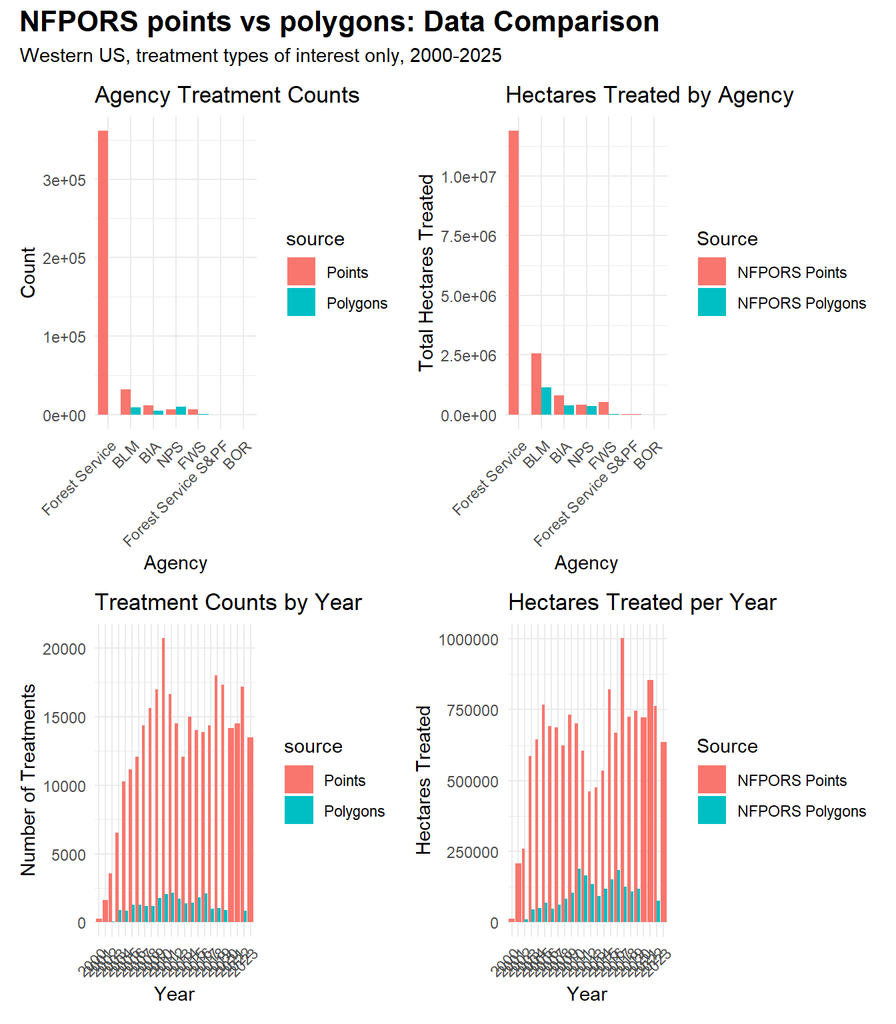

```r
# Get counts
years_to_show <- 2000:2025

#glimpse(nfpors_poly)
nfpors_poly_agency_count <- nfpors_poly |>
  sf::st_drop_geometry() |>
  dplyr::count(agency)
# nfpors_poly_agency_count
# nfpors_agency_count
nfpors_agency_count <- nfpors_interest |>
  sf::st_drop_geometry() |>
  dplyr::count(agencyname)

# Add source labels
poly_agency <- nfpors_poly_agency_count |>
  mutate(source = "Polygons")

attr_agency <- nfpors_agency_count |>
  mutate(source = "Points") |>
  rename(agency = agencyname)

# Combine both
combined_agency_counts <- bind_rows(poly_agency, attr_agency) #|>
  #filter(agency != "Forest Service")

# Plot
pp1 <- ggplot(combined_agency_counts, aes(x = reorder(agency, -n), y = n, fill = source)) +
  geom_bar(stat = "identity", position = "dodge") +
  labs(
    title = "Agency Treatment Counts",
    x = "Agency",
    y = "Count"
  ) +
  theme_minimal() +
  theme(axis.text.x = element_text(angle = 45, hjust = 1))

# Count number of polygon treatments by year
nfpors_poly_year <- nfpors_poly |>
  st_drop_geometry() |>
  count(year) |>
  mutate(source = "Polygons") |>
  rename(Year = year)

# Count number of point treatments by year
nfpors_point_year <- nfpors_interest |>
  st_drop_geometry() |>
  count(actualcompletionyear) |>
  mutate(source = "Points") |>
  rename(Year = actualcompletionyear)

# Combine
nfpors_year_counts <- bind_rows(nfpors_poly_year, nfpors_point_year) |>
  filter(Year %in% years_to_show)

# Plot
pp2 <- ggplot(nfpors_year_counts, aes(x = factor(Year), y = n, fill = source)) +
  geom_bar(stat = "identity", position = "dodge") +
  labs(
    title = "Treatment Counts by Year",
    x = "Year",
    y = "Number of Treatments"
  ) +
  theme_minimal() +
  theme(axis.text.x = element_text(angle = 45, hjust = 1))

# NFPORS polygons: hectares by year
nfpors_poly_hectares_year <- nfpors_poly |>
  st_drop_geometry() |>
  group_by(year) |>
  summarise(hectares = sum(hectares, na.rm = TRUE), .groups = "drop") |>
  mutate(Source = "NFPORS Polygons") |>
  rename(Year = year)

# NFPORS points: hectares by year
nfpors_point_hectares_year <- nfpors_interest |>
  group_by(actualcompletionyear) |>
  summarise(hectares = sum(hectares, na.rm = TRUE), .groups = "drop") |>
  mutate(Source = "NFPORS Points") |>
  rename(Year = actualcompletionyear)

# Combine and plot
nfpors_yearly_hectares_comparison <- bind_rows(nfpors_poly_hectares_year, nfpors_point_hectares_year) |>
  filter(Year %in% years_to_show)

pp3 <- ggplot(nfpors_yearly_hectares_comparison, aes(x = factor(Year), y = hectares, fill = Source)) +
  geom_bar(stat = "identity", position = "dodge") +
  labs(
    x = "Year",
    y = "Hectares Treated",
    title = "Hectares Treated per Year"
  ) +
  theme_minimal() +
  theme(axis.text.x = element_text(angle = 45, hjust = 1))

# NFPORS polygons: hectares by agency
nfpors_poly_agency_hectares <- nfpors_poly |>
  st_drop_geometry() |>
  group_by(agency) |>
  summarise(hectares = sum(hectares, na.rm = TRUE), .groups = "drop") |>
  mutate(Source = "NFPORS Polygons")

# NFPORS points: hectares by agency
nfpors_point_agency_hectares <- nfpors_interest |>
  group_by(agencyname) |>
  summarise(hectares = sum(hectares, na.rm = TRUE), .groups = "drop") |>
  mutate(Source = "NFPORS Points") |>
  rename(agency = agencyname)

# Combine and plot
nfpors_agency_hectares_comparison <- bind_rows(nfpors_poly_agency_hectares, nfpors_point_agency_hectares) |>
  filter(!is.na(agency))

pp4 <- ggplot(nfpors_agency_hectares_comparison, aes(x = reorder(agency, -hectares), y = hectares, fill = Source)) +
  geom_bar(stat = "identity", position = "dodge") +
  labs(
    x = "Agency",
    y = "Total Hectares Treated",
    title = "Hectares Treated by Agency"
  ) +
  theme_minimal() +
  theme(axis.text.x = element_text(angle = 45, hjust = 1))

pp <- (pp1 + pp4) / (pp2 + pp3) +
    plot_annotation(
      title = "NFPORS points vs polygons: Data Comparison",
      subtitle = "Western US, treatment types of interest only, 2000-2025",
      theme = theme(plot.title = element_text(size = 16, face = "bold")))
pp
```

# Are there matching treatment IDs for the NFPORS polygons?

The objectid’s don’t match, but the treatment IDs appear to match. The vast majority of the polygons have a match.

There are different treated areas recorded in the different datasets, but the difference histogram is centered on zero.

```r
# x <- nfpors_poly |>
#   sf::st_drop_geometry() |>
#   mutate(objectid = as.integer(objectid)) |>
#   inner_join(nfpors, by = join_by(objectid))
#
# ggplot() +
#   geom_point(data = x, aes(x = hectares.x, y = hectares.y))
#
#
# ggplot() +
#   geom_point(data = x, aes(x = fy, y = completedfy)) +
#   ylim(c(2000, 2025))

matched_nfpors <- nfpors_poly |>
  sf::st_drop_geometry() |>
  inner_join(nfpors_interest, by = join_by(trt_id == treatmentid))

nrow(matched_nfpors)
```

```
[1] 24132
```

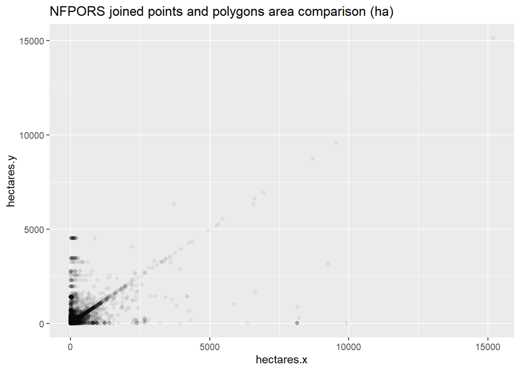

```r
ggplot() +
  geom_point(data = matched_nfpors, aes(x = hectares.x, y = hectares.y), alpha = 0.05)+
  labs(title = "NFPORS joined points and polygons area comparison (ha)")
```

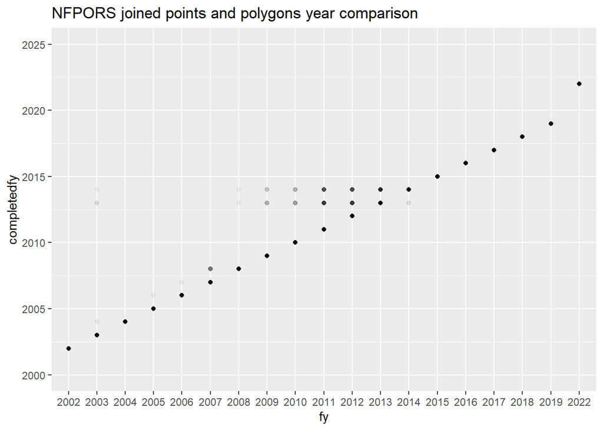

```r
ggplot() +
  geom_point(data = matched_nfpors, aes(x = fy, y = completedfy), alpha = 0.05) +
  ylim(c(2000, 2025))+
  labs(title ="NFPORS joined points and polygons year comparison")
```

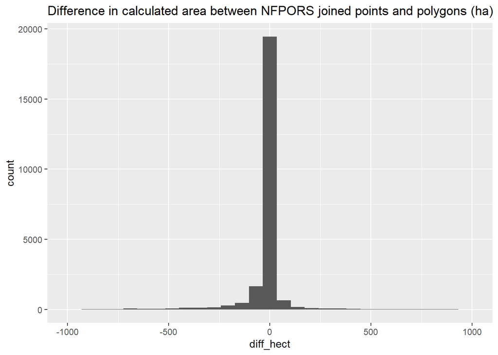

```r
matched_nfpors <- matched_nfpors |>
  mutate(diff_hect = hectares.x - hectares.y)

ggplot() +
  geom_histogram(data = matched_nfpors, aes(x = diff_hect)) +
  xlim(c(-1000, 1000)) +
  labs(title = "Difference in calculated area between NFPORS joined points and polygons (ha)")
```

# Check if FACTS IDs match

They don’t :/ There appears to be no way to explicitly match the USFS data in FACTS & NFPORS. For USFS data, FACTS should be used and the USFS data in NFPORS should be discarded.

```r
matched_facts <- facts |>
  sf::st_drop_geometry() |>
  inner_join(nfpors_interest, by = join_by(FACTS_ID == treatmentid))
glue::glue("Matched FACTS: {nrow(matched_facts)}")
```

```
Matched FACTS: 0
```